# Analyzing and Interpreting Shark Attacks

## By: Henry Martinez

## Introduction

One of the most feared predators of the ocean, the shark. Today we’re gonna find out how scared we should be of what has infamously been portrayed as a man-eating beast. Let’s ask these questions:

**Which State in the USA has the most reported shark attacks?**

**What type of shark attack occurs the most among women & among men ?**

**What age group makes up the most shark attacks?**

My project looks at over 6,000 reported cases of shark attacks including that area the attack took place, country, age and name of victim, and so on.

## Requirements

```r
library(tidyverse)
library(dplyr)
library(ggplot2)
library(scales)
library(readxl)
#libraries needed for this project
```

## Dataset

Some variable values were changed to makes working with the dataset much easier and more acceisble.

```r
#Some variables had to be modified to numeric to make it possible to work with the dataset

library(readxl)
GSAF5_1 <- read_excel("F:/Downloads/DataSets/GSAF5-1.xls/GSAF5-1.xls",
    col_types = c("text", "text", "numeric",
        "text", "text", "text", "text", "text",
        "text", "text", "numeric", "text",
        "text", "text", "text", "text", "text",
        "text", "text", "text", "text", "text",
        "numeric", "numeric"))
```

```r
head(GSAF5_1)
```

```
## # A tibble: 6 x 24
##   `Case Number...~ Date   Year Type  Country Area  Location Activity Name  Sex
##   <chr>            <chr> <dbl> <chr> <chr>   <chr> <chr>    <chr>    <chr> <chr>
## 1 2019.08.27       27-A~  2019 Prov~ USA     Flor~ New Smy~ Surfing  Dona~ M
## 2 2019.08.21       21-A~  2019 Unpr~ USA     Flor~ Fort La~ Wading   Chri~ M
## 3 2019.08.20       20-A~  2019 Unpr~ USA     Hawa~ Napoopo~ Swimming fema~ F
## 4 2019.08.16       16-A~  2019 Unpr~ USA     Flor~ New Smy~ Wading   Magg~ M
## 5 2019.08.11       11-A~  2019 Unpr~ USA     Hawa~ Makaha ~ Surfing  Max ~ M
## 6 2019.08.04       04-A~  2019 Unpr~ USA     Flor~ New Smy~ Standing Pete~ M
## # ... with 14 more variables: Age <dbl>, Injury <chr>, Fatal (Y/N) <chr>,
## #   Time <chr>, Species <chr>, Investigator or Source <chr>, pdf <chr>,
## #   href formula <chr>, href <chr>, Case Number...20 <chr>,
## #   Case Number...21 <chr>, original order <chr>, ...23 <dbl>, ...24 <dbl>
```

## Understading Missing Values

In this dataset there are several missing values. To better understand this data and get a better view of what we are missing lets see how many observations are missing their age value.

```r
GSAF5_1 %>%
    filter(is.na(Age))
```

```
## # A tibble: 22,161 x 24
##    `Case Number...1` Date    Year Type   Country  Area  Location  Activity Name
##    <chr>             <chr>  <dbl> <chr>  <chr>    <chr> <chr>     <chr>    <chr>
##  1 2019.07.30        30-Ju~  2019 Provo~ USA      Nort~ Off Cape~ Fishing  Rick~
##  2 2019.07.28        28-Ju~  2019 Unpro~ AUSTRAL~ Quee~ Magra Is~ Snorkel~ fema~
##  3 2019.07.18        18-Ju~  2019 Uncon~ USA      Flor~ Haulover~ Diving   <NA>
##  4 2019.07.16        16-Ju~  2019 Unpro~ USA      Nort~ Sunset B~ Body-su~ Meli~
##  5 2019.07.06        06-Ju~  2019 Provo~ MEXICO   Quin~ Cabo Cat~ Fishing  Edga~
##  6 2019.06.21        21-Ju~  2019 Unpro~ BAHAMAS  Abac~ <NA>      Spearfi~ Jona~
##  7 2019.06.06.R      Repor~  2019 Unpro~ AUSTRAL~ Tasm~ Maatsuyk~ Abalone~ male
##  8 2019.06.05        05-Ju~  2019 Unver~ AUSTRAL~ New ~ Lennox H~ Surfing  male
##  9 2019.05.14.b      14-Ma~  2019 Unpro~ USA      Hawa~ Browns, ~ Surfing  male
## 10 2019.05.01        01-Ma~  2019 Unpro~ USA      Flor~ Off Boca~ Fishing  Paul~
## # ... with 22,151 more rows, and 15 more variables: Sex <chr>, Age <dbl>,
## #   Injury <chr>, Fatal (Y/N) <chr>, Time <chr>, Species <chr>,
## #   Investigator or Source <chr>, pdf <chr>, href formula <chr>, href <chr>,
## #   Case Number...20 <chr>, Case Number...21 <chr>, original order <chr>,
## #   ...23 <dbl>, ...24 <dbl>
```

```r
GSAF5_1 %>%
    filter(!is.na(Age))
```

```
## # A tibble: 3,599 x 24
##    `Case Number...1` Date    Year Type   Country Area  Location   Activity Name
##    <chr>             <chr>  <dbl> <chr>  <chr>   <chr> <chr>      <chr>    <chr>
##  1 2019.08.27        27-Au~  2019 Provo~ USA     Flor~ New Smyrn~ Surfing  Dona~
##  2 2019.08.21        21-Au~  2019 Unpro~ USA     Flor~ Fort Laud~ Wading   Chri~
##  3 2019.08.20        20-Au~  2019 Unpro~ USA     Hawa~ Napoopoo ~ Swimming fema~
##  4 2019.08.16        16-Au~  2019 Unpro~ USA     Flor~ New Smyrn~ Wading   Magg~
##  5 2019.08.11        11-Au~  2019 Unpro~ USA     Hawa~ Makaha Be~ Surfing  Max ~
##  6 2019.08.04        04-Au~  2019 Unpro~ USA     Flor~ New Smyrn~ Standing Pete~
##  7 2019.08.03.c      03-Au~  2019 Unpro~ USA     Flor~ New Smyrn~ Surfing  Rile~
##  8 2019.08.03.b      03-Au~  2019 Unpro~ USA     Flor~ New Smyrn~ Surfing  Emil~
##  9 2019.08.03.a      03-Au~  2019 Unpro~ USA     Flor~ Off Key B~ Spearfi~ Mari~
## 10 2019.07.29        29-Ju~  2019 Unpro~ USA     Flor~ New Smyrn~ Surfing  Reed~
## # ... with 3,589 more rows, and 15 more variables: Sex <chr>, Age <dbl>,
## #   Injury <chr>, Fatal (Y/N) <chr>, Time <chr>, Species <chr>,
## #   Investigator or Source <chr>, pdf <chr>, href formula <chr>, href <chr>,
## #   Case Number...20 <chr>, Case Number...21 <chr>, original order <chr>,
## #   ...23 <dbl>, ...24 <dbl>
```

Seeing as how more than 3/4 of the data is missing we will later create a mew Dataset filtering out these unwanted vlaues.

### Data Exploration

Let’s take a peek into the dataset we will be exploring for today

```r
summary(GSAF5_1)
```

```
##  Case Number...1        Date                Year           Type
##  Length:25760       Length:25760       Min.   :   0    Length:25760
##  Class :character   Class :character   1st Qu.:1942    Class :character
##  Mode  :character   Mode  :character   Median :1980    Mode  :character
##                                        Mean   :1930
##                                        3rd Qu.:2006
##                                        Max.   :2019
##                                        NA's   :19311
##    Country              Area             Location           Activity
##  Length:25760       Length:25760       Length:25760       Length:25760
##  Class :character   Class :character   Class :character   Class :character
##  Mode  :character   Mode  :character   Mode  :character   Mode  :character
##
##
##
##
##      Name               Sex                 Age           Injury
##  Length:25760       Length:25760       Min.   : 0.30   Length:25760
##  Class :character   Class :character   1st Qu.:17.00   Class :character
##  Mode  :character   Mode  :character   Median :24.00   Mode  :character
##                                        Mean   :27.46
##                                        3rd Qu.:35.00
##                                        Max.   :87.00
##                                        NA's   :22161
##  Fatal (Y/N)            Time             Species
##  Length:25760       Length:25760       Length:25760
##  Class :character   Class :character   Class :character
##  Mode  :character   Mode  :character   Mode  :character
##
##
##
##
##  Investigator or Source     pdf            href formula
##  Length:25760           Length:25760       Length:25760
##  Class :character       Class :character   Class :character
##  Mode  :character       Mode  :character   Mode  :character
##
##
##
##
##      href           Case Number...20   Case Number...21   original order
##  Length:25760       Length:25760       Length:25760       Length:25760
##  Class :character   Class :character   Class :character   Class :character
##  Mode  :character   Mode  :character   Mode  :character   Mode  :character
##
##
##
##
##      ...23           ...24
##  Min.   : NA     Min.   : NA
##  1st Qu.: NA     1st Qu.: NA
##  Median : NA     Median : NA
##  Mean   :NaN     Mean   :NaN
##  3rd Qu.: NA     3rd Qu.: NA
##  Max.   : NA     Max.   : NA
##  NA's   :25760   NA's   :25760
```

Since this dataset is from an excel that has many blank rows, I will make a separate dataframe that excludes all those blank rows.

```r
UseThis <- GSAF5_1 %>%
    filter(Year > 0)
```

```r
UseThis %>%
    select(Country, Area, Year, Type) %>%
    unique()
```

```
## # A tibble: 3,930 x 4
##    Country      Area                   Year Type
##    <chr>        <chr>                 <dbl> <chr>
##  1 USA          Florida                2019 Provoked
##  2 USA          Florida                2019 Unprovoked
##  3 USA          Hawaii                 2019 Unprovoked
##  4 USA          North Carolina         2019 Provoked
##  5 AUSTRALIA    Queensland             2019 Unprovoked
##  6 USA          Rhode Island           2019 Unprovoked
##  7 USA          Florida                2019 Unconfirmed
##  8 NEW ZEALAND  Chatham Islands        2019 Unprovoked
##  9 USA          North Carolina         2019 Unprovoked
## 10 SOUTH AFRICA Eastern Cape Province  2019 Unprovoked
## # ... with 3,920 more rows
```

## Univariate Exploration

We’ll start analyzing our data though univariation based on specific fields. We will also be testing the integrity of the data to make sure it is viable for real world representations.

## Frequency On Sex

The Visualization below is the Distribution of shark attacks based off of sex. The graph also shows the amount of observation without a value for sex. However, we can extrapolate and say that the current trend of Males being targeted by sharks more than females can be applied to a larger sample size. Furthermore, We can see that unprovoked occurences of shark attacks are most common among both males and females.

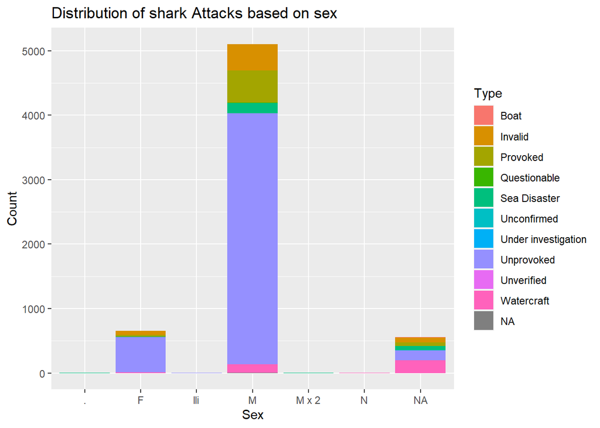

```r
UseThis %>%

    ggplot(aes( x = Sex,fill = Type)) +
    geom_bar(
        bins = 50,
        na.rm = TRUE,

    )+
   scale_y_continuous(


    )+
    labs(title = "Distribution of shark Attacks based on sex",
         x = "Sex",
         y = "Count")
```

## Years

From the Visualization below we can tell that 2015 had the highest number of shark attacks reported and no pattern can be differed from the first graph. The second graph below shows the full distribution of shark attacks. Here we can see a sharp increase in shark attacks as it approaches the 21st century. The graph also peaks somewhere in the 1960s, also known as the cultural decade. People were finally losing their war fatigue and likely going out to celebrate, which would make sense considering more people would be at the shoreline.

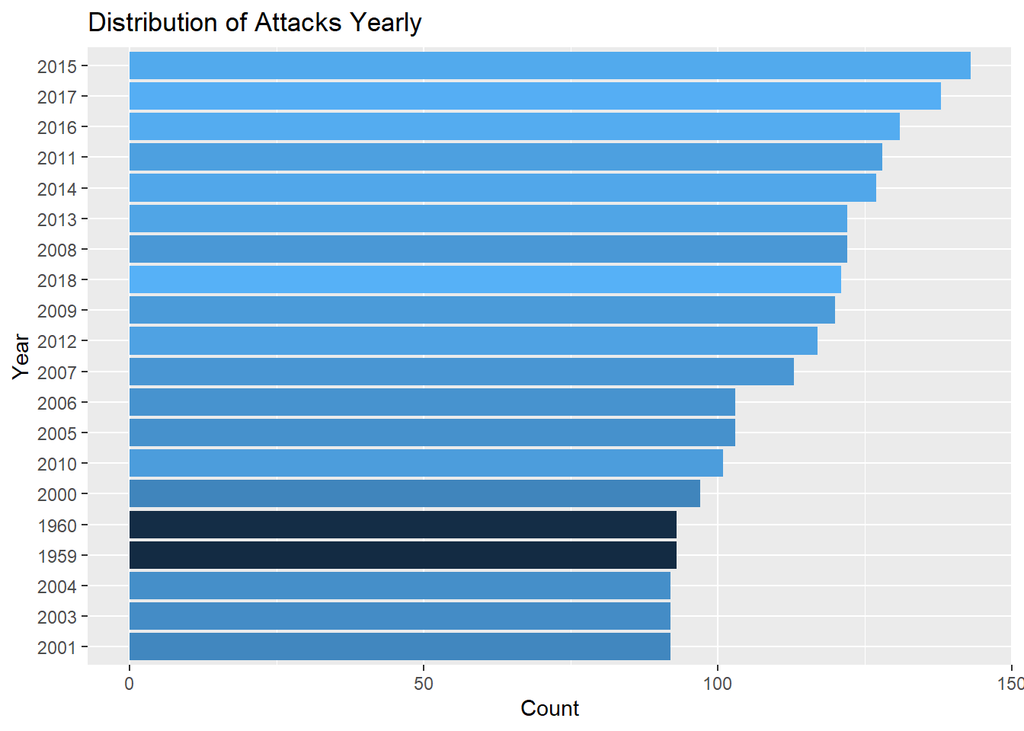

```r
UseThis %>%
group_by(Year) %>%
  summarise(count = n()) %>%
  arrange(desc(count)) %>%
  slice(1:20) %>%
  ggplot() +
  geom_col(
    mapping = aes(
      x= reorder(Year, count),
      fill = Year,
      y = count)) +
  labs(
    title = "Distribution of Attacks Yearly",
    x = "Year",
    y = "Count") +
  theme(legend.position = "none") +
  coord_flip()
```

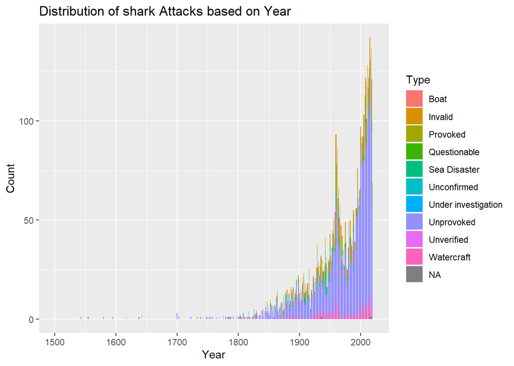

```r
UseThis %>%

    ggplot() +
    geom_bar(
        aes( x = Year, fill = Type),
        bins = 50,
        na.rm = TRUE


    )+
   scale_x_continuous(
        limits = c(1500, 2020)

    )+
    labs(title = "Distribution of shark Attacks based on Year",
         x = "Year",
         y = "Count")
```

## Country

To better understand the distribution of attacks in the country of the USA, I made a visualization that displays each areas in the US a shark attack was reported and the quantity of each area. Below that is a visualization of the age group in the US that made up the majority of these shark attacks.

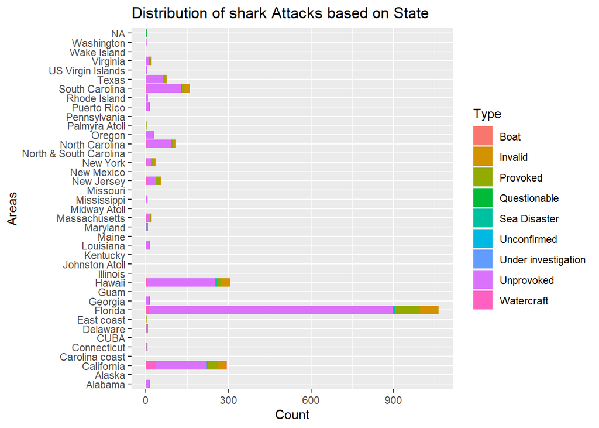

```r
UseThis %>%
    filter(Country == "USA") %>%

    ggplot()+
    geom_bar(
        aes(y = Area, fill = Type)
    )+
    labs(title = "Distribution of shark Attacks based on State",
         x = "Count",
         y = "Areas")
```

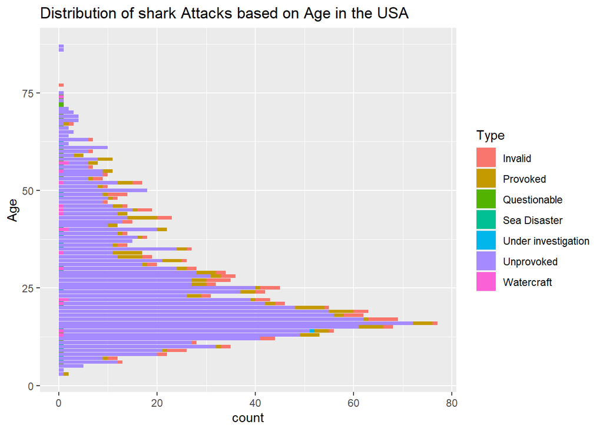

```r
UseThis %>%
    filter(Country == "USA") %>%

    ggplot()+
    geom_bar(
        aes(y = Age, fill = Type)
    )+
    labs(title = "Distribution of shark Attacks based on Age in the USA",
         x = "count",
         y = "Age")
```

## Multivariate Exploration

The First Multi-Chart graph seen is showing the distribution of shark attacks by age. The Y-value determines if the attack was on a Male or Female and each chart itself represents a certain type of attack which are listed on the side. With this graph we can compare each type of attack with each other and discover that unprovoked has a wider range of age while still being centered on around 23 years old. The second graph is a density chart showing the relationship between age and year. This shows which year has what concentration of age as well as what type of attack it was.

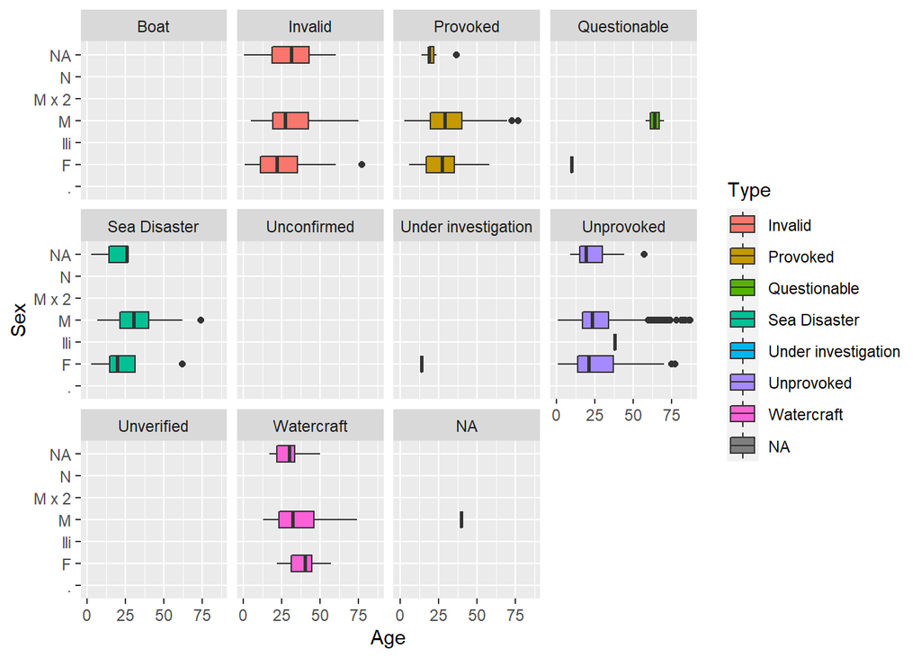

```r
UseThis %>%
  ggplot(aes(x=Age, y=Sex, fill=Type)) +
    geom_boxplot()+
    facet_wrap(~Type)
```

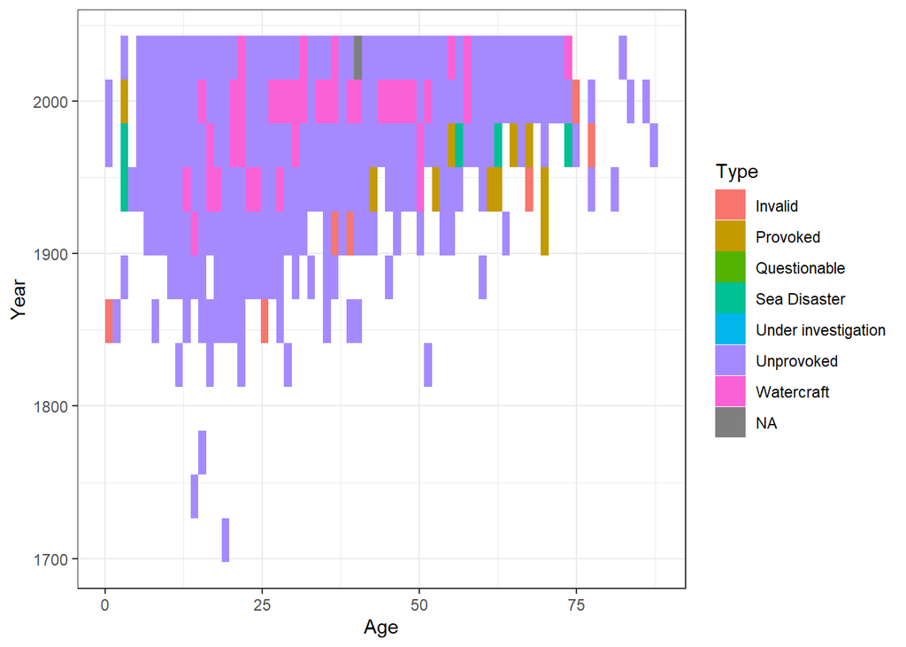

```r
UseThis %>%
ggplot(aes(x=Age, y=Year, fill = Type) ) +
  geom_bin2d(bins = 70) +
  theme_bw()
```

## Which State in the USA has the most reported shark attacks?

A simple value metric we can determine through filtering and grouping the data

```r
UseThis %>%
     filter(Country == "USA") %>%
   group_by(Area) %>%
    summarise(Total = sum(n())) %>%
    arrange(desc(Total)) %>%
    head(1)
```

```
## # A tibble: 1 x 2
##   Area    Total
##   <chr>   <int>
## 1 Florida  1064
```

## What type of shark attack occurs the most among women & among men ?

To determine these values the data was grouped by sex and the type of attack. A new value called “Total” was then created to count the total number of rows and then arranged to show the greates value first. Unprovoked proved to be the highest among both sexes.

```r
UseThis %>%
    group_by(Type, Sex) %>%
    summarise(total = sum(n(), na.rm = T)) %>%
    arrange(desc(total)) %>%
    head(2)
```

```
## # A tibble: 2 x 3
## # Groups:   Type [1]
##   Type       Sex   total
##   <chr>      <chr> <int>
## 1 Unprovoked M      3894
## 2 Unprovoked F       546
```

## What age group makes up the most shark attacks?

To determine this metric all the N/A values were first filtered out and then grouped by age. Once more a total value was made to determine the sum of the number of rows and then the arranged by descending order. The first value was 17 years old.

```r
UseThis %>%
    filter(Age > 0) %>%
    group_by(Age) %>%
    summarise(Total = sum(n(), na.rm = T)) %>%
    arrange(desc(Total)) %>%
    head(1)
```

```
## # A tibble: 1 x 2
##     Age Total
##   <dbl> <int>
## 1    17   164
```

## Which Country has the most shark Attacks?

This was determined by grouping the data via country and creating a total value to sum up the rows. The data was again arranged in descending order and the first value was the USA.

```r
UseThis %>%
   group_by(Country) %>%
    summarise(Total = sum(n())) %>%
    arrange(desc(Total)) %>%
    head(1)
```

```
## # A tibble: 1 x 2
##   Country Total
##   <chr>   <int>
## 1 USA      2293
```

## What More Could be Done?

This dataset still has limitless possibilities and this project only scratches the surface of it. A probability chart can be constructed that would determine the likelihood of you getting in a shark attack depending on your age, sex, and location. Statistical learning models could also be formed using more sophisticated methods to determine areas of “high danger” or increased likelihoods. The imagination is the only limitation to what could be done with this and other sets of data, time will only tell just how many problems we can solve or prevent through data manipulation.

## Dataset Cited

You can find the dataset I used from [This](https://www.kaggle.com/ncsaayali/shark-attack-dataset/metadata) site.